# Creating Slides

**Assuming you have `ls = ipyslides.LiveSlides()`**

- Proceed to create slides:
  - Edit and test cells in `ls.convert2slides(False)` mode.
  - Run cells in `ls.convert2slides(True)` mode from top to bottom.
  - `%%slide integer` on cell top auto picks slide and `%%title` auto picks title page.
  - `%%slide integer -m` can be used to create slide from full markdown (extended one).
  - You can use context managers like `with ls.slide(): ...` and `with ls.title(): ...` in place of `%%slide` and `%%title` respectively.

Python

```
import ipyslides as isd
ls = isd.LiveSlides()
ls.settings.set_animation('zoom')
```

Python

```
%%title
# create a rich content title page
```

Python

```
%%slide 1
# slide 1 content
```

Python

````
%%slide 1 -m # new in 1.4.6
**Markdown here with extended options. Nested blocks are not supported**
 ```multicol 30 70 .Success
 less content
 +++
 more content
 ```
````

**Markdown here with extended options. Nested blocks are not supported**

less content

more content

3

There is a python block above with header `python run source`. We can display that block by {{source}} as below:

Python

```
x = 1 + 2
print(x) # will be printed on slide in somehwewere top as print appears first of all.
# Use `ls.print_context():  print()` to see at exactly where it is printed.
```

variable `x` defined there is shown here x = 3. Only variables can be embeded in {{var}}, not expressions.

Python

```
@ls.frames(1,*objs)
def func(obj):
    write(obj) #This will create as many slides after the slide number 1 as length(objs)
```

Python

```
ls # This displays slides if on the last line of cell, or use `ls.show()`.
```

- Use `ls.from_markdown` to create slides from markdown file/StringIO and then can add slides over it.
  - Slides are added in order of content.
  - Slides should be separated by `---` (three dashes) in start of line.
  - You can add more slides besides created ones or modify existing ones using `ls.md_content`:

Python

```
ls.from_markdown(path)
with ls.slide(2):
    write(ls.md_content[2]) # write content of slide 2 from file
    plot_something() # Add other things to same file
    write_something()
```

- Use `ls.demo` to create example slides and start editing. Follow steps in first part.
- Use `ls.load_docs` to see upto date documentation.

#### 👈🏻 Read more instructions in left panel

# Slide 1

#### This is inline markdown parsed by magic

Version: 1.5.1 as executed from below code in markdown.

Python

```
import ipyslides as isd
version = isd.__version__
%xmd #### This is inline markdown parsed by magic {.Note .Warning}
```

## I am created using `with slides.slide(1)` context( manager!

I am Alerted and I am *colored and italic text*

Python

```
slides.parse_xmd(slides.md_content[1])
#display(*get_ipython().user_ns['outputs'])
write('## I am created using `with slides.slide(1)` context( manager!')
write(f'I am {slides.alert("Alerted")} and I am *{slides.colored("colored and italic text","magenta","whitesmoke")}*')
```

1/22

# Slide 2

Created using `%%slide 2 -m` with markdown only

# Column A

### Sub column A

### Sub column B

# Column B

That version from last slide is still in memory. See it is there 1.5.1

2/22

## I am created using `@slides.frames`

Python

```
slides.write(obj)
slides.notify_later()(lambda: 'That is a notification which shows you can use decorator this way as well')
```

3.1/22

# IPySlides Online Running Sources

Launch as voila slides (may not work as expected <sup>1</sup>)

[Edit on Kaggle](https://www.kaggle.com/massgh/ipyslides)

Launch example Notebook

[^1]: Add references like this per slide. Use slides.cite() to add citations generally.

Python

```
slides.write(obj)
slides.notify_later()(lambda: 'That is a notification which shows you can use decorator this way as well')
```

3.2/22

## IPython Display Objects

#### Any object with following methods could be in`write` command:

`_repr_pretty_`, `_repr_html_`, `_repr_markdown_`, `_repr_svg_`, `_repr_png_`, `_repr_jpeg_`, `_repr_latex_`, `_repr_json_`, `_repr_javascript_`, `_repr_pdf_` Such as `IPython.display.<HTML,SVG,Markdown,Code>` etc. or third party such as `plotly.graph_objects.Figure`.

4/22

## Plots and Other **Data** Types

#### These objects are implemented to be writable in `write` command:

`matplotlib.pyplot.Figure`, `altair.Chart`, `pygal.Graph`, `pydeck.Deck`, `pandas.DataFrame`, `bokeh.plotting.Figure`, `IPython.display.Image` Many will be extentended in future. If an object is not implemented, use `display(obj)` to show inline or use library's specific command to show in Notebook outside `write`.

5/22

## Interactive Widgets

### Any object in `ipywidgets`[Link to ipywidgtes right here using `textbox` command](https://ipywidgets.readthedocs.io/en/latest/)

or libraries based on ipywidgtes such as `bqplot`,`ipyvolume`,plotly's `FigureWidget`<sup>1</sup>(reference at end) can be included in `iwrite` command as well as other objects that can be passed to `write` with caveat of Javascript.

6/22

## Commands which do all Magic!

LiveSlides.**write**(*columns, width_percents=None, className=None)

Writes markdown strings or IPython object with method `_repr_<html,svg,png,...>_` in each column of same with. If width_percents is given, column width is adjusted. Each column should be a valid object (text/markdown/html/ have *repr* *or to* method) or list/tuple of objects to form rows or explictly call `rows`.

- Pass int,float,dict,function etc. Pass list/tuple in a wrapped list for correct print as they used for rows writing too.
- Give a code object from `LiveSlides.source.context[from_...]` to it, syntax highlight is enabled.
- Give a matplotlib `figure/Axes` to it or use `ipyslides.objs_formatter.plt2html()`.
- Give an interactive plotly figure.
- Give a pandas dataframe `df` or `df.to_html()`.
- Give any object which has `to_html` method like Altair chart. (Note that chart will not remain interactive, use display(chart) if need interactivity like brushing etc.)
- Give an IPython object which has `_repr_<repr>_` method where is one of ('html','markdown','svg','png','jpeg','javascript','pdf','pretty','json','latex').
- Give a function/class/module (without calling) and it will be displayed as a pretty printed code block.

If an object is not in above listed things, `obj.__repr__()` will be printed. If you need to show other than **repr**, use `display(obj)` outside `write` command or use methods specific to that library to show in jupyter notebook.

If you give a className, add CSS of it using `format_css` function and provide it to `write` function. Get a list of already available classes using `slides.css_styles`. For these you dont need to provide CSS.

Note: Use `keep_format` method to bypass markdown parser, for example `keep_format(altair_chart.to_html())`. Note: You can give your own type of data provided that it is converted to an HTML string. Note: `_repr_<format>_` takes precedence to `to_<format>` methods. So in case you need specific output, use `object.to_<format>`.

LiveSlides.**iwrite**(*columns, width_percents=None, className=None)

Each obj in columns could be an IPython widget like `ipywidgets`,`bqplots` etc or list/tuple (or wrapped in `rows` function) of widgets to display as rows in a column. Other objects (those in `write` command) will be converted to HTML widgets if possible. Object containing javascript code may not work, use `write` command for that.

If you give a className, add CSS of it using `format_css` function and provide it to `iwrite` function. Get a list of already available classes using `slides.css_styles`. For these you dont need to provide CSS.

**Returns**: writer, columns as reference to use later and update. rows are packed in columns.

**Examples**:

Python

```
writer, x = iwrite('X')
writer, (x,y) = iwrite('X','Y')
writer, (x,y) = iwrite(['X','Y'])
writer, [(x,y),z] = iwrite(['X','Y'],'Z')
#We unpacked such a way that we can replace objects with new one using `grid.update`
new_obj = writer.update(x, 'First column, first row with new data') #You can update same `new_obj` with it's own widget methods.
```

LiveSlides.**parse_xmd**(extended_markdown, display_inline=True, rich_outputs=False)

Parse extended markdown and display immediately. If you need output html, use display_inline = False but that won't execute python code blocks. Precedence of content return/display is: rich_outputs = True > display_inline = True > parsed_html_string

You can use the following syntax:

````
```python run var_name
# If no var_name, code will be executed without assigning it to any variable
import numpy as np
```
# Normal Markdown {.report-only}
```multicol 40 60
# First column is 40% width
If 40 60 was not given, all columns will be of equal width
+++
# Second column is 60% wide
This \{\{var_name\}\} is code from above and will be substituted with the value of var_name
```

```python
# This will not be executed, only shown
```
Inline-column A Inline-column B
````

Each block can have a class name (in 1.4.7+) after all other options such as `python .friendly` or `multicol .Sucess`. For example, `python .friendly` will be highlighted with friendly theme from pygments. Pygments themes, however, are not supported with `multicol`. Aynthing with class name 'report-only' will not be displayed on slides, but appears in document when `LiveSlides.display_html` is called.

Note: Nested blocks are not supported. New in 1.4.6

#### If an object does not render as you want, use `display(object)` or it's own library's mehod to display inside Notebook.

Python

```
write([slides.doc(write,'LiveSlides'), slides.doc(iwrite,'LiveSlides'), slides.doc(slides.parse_xmd,'LiveSlides')])
write("#### If an object does not render as you want, use `display(object)` or it's own library's mehod to display inside Notebook.")
```

7/22

## Plotting with Matplotlib

[figure not shown]

Python

```
import numpy as np, matplotlib.pyplot as plt
x = np.linspace(0,2*np.pi)
with plt.style.context('ggplot'):
    fig, ax = plt.subplots(figsize=(3.4,2.6))
    _ = ax.plot(x,np.cos(x))
write([ax, s.focus_lines([1,3,4])])
```

8/22

### Watching Youtube Video?

[video not shown]

Python

```
write(f"### Watching Youtube Video?")
write(YouTubeVideo('Z3iR551KgpI',width='100%',height='266px'))
@slides.notify_later()
def push():
    t = time.localtime()
    return f'You are watching Youtube at Time-{t.tm_hour:02}:{t.tm_min:02}'

write(s) # source.context(style='vs',background='#FAA',className="Youtube")
```

9/22

## Data Tables

**Here is Table**

| h1 | h2 | h3 |
| --- | --- | --- |
| d1 | d2 | d3 |
| r1 | r2 | r3 |

Python

```
write('## Data Tables')
write(slides.block_r('Here is Table',
    textwrap.dedent('''
    |h1|h2|h3|
    |---|---|---|
    |d1|d2|d3|
    |r1|r2|r3|
    ''')))
write(s.focus_lines([3,4,5,6]))
```

10/22

## Writing Pandas DataFrame

|  | sepal_length | sepal_width | petal_length | petal_width |
| --- | --- | --- | --- | --- |
| count | 150.000000 | 150.000000 | 150.000000 | 150.000000 |
| mean | 5.843333 | 3.057333 | 3.758000 | 1.199333 |
| std | 0.828066 | 0.435866 | 1.765298 | 0.762238 |
| min | 4.300000 | 2.000000 | 1.000000 | 0.100000 |
| 25% | 5.100000 | 2.800000 | 1.600000 | 0.300000 |
| 50% | 5.800000 | 3.000000 | 4.350000 | 1.300000 |
| 75% | 6.400000 | 3.300000 | 5.100000 | 1.800000 |
| max | 7.900000 | 4.400000 | 6.900000 | 2.500000 |

## Writing Altair Chart

May not work everywhere, needs javascript

[interactive chart not shown]

Python

```
 + 5 more lines ...     chart = alt.Chart(df,width=300,height=260).mark_circle(size=60).encode(
        x='sepal_length',
        y='sepal_width',
        color='species',
        size = 'petal_width',
        tooltip=['species', 'sepal_length', 'sepal_width','petal_width','petal_length']
        ).interactive()
 + 5 more lines ...
```

11/22

## Writing Plotly Figure

### Install `plotly` to view output

12/22

## Interactive Apps on Slide

Use `ipywidgets`, `bqplot`,`ipyvolume` , `plotly Figurewidget` etc. to show live apps like this!

13/22

### This is Slide 14.1

and we are animating matplotlib

Python

```
fig, ax = plt.subplots()
 + 6 more lines ...
```

[figure not shown]

Python

```
 + 5 more lines ... slides.notes.insert(f'## This is under @frames decorator, so it will be shown only in first frame')
slides.notify_later()(lambda: f'This is under @frames decorator, so it will be shown only in first frame')
```

14.1/22

### This is Slide 14.2

and we are animating matplotlib

Python

```
 + 1 more lines ... x = np.linspace(0,obj+1,50+10*(obj - 13))
 + 5 more lines ...
```

[figure not shown]

14.2/22

### This is Slide 14.3

and we are animating matplotlib

Python

```
 + 2 more lines ... ax.plot(x,np.sin(x));
 + 4 more lines ...
```

[figure not shown]

14.3/22

### This is Slide 14.4

and we are animating matplotlib

Python

```
 + 3 more lines ... ax.set_title(f'$f(x)=\sin(x)$, 0 < x < {obj - 13}')
 + 3 more lines ...
```

[figure not shown]

14.4/22

### This is Slide 14.5

and we are animating matplotlib

Python

```
 + 4 more lines ... ax.set_axis_off()
 + 2 more lines ...
```

[figure not shown]

14.5/22

# Frames with

#### `repeat = False`

# 1

15.1/22

# Frames with

#### `repeat = False`

# 2

15.2/22

# Frames with

#### `repeat = False`

# 3

15.3/22

# Frames with

#### `repeat = False`

# 4

15.4/22

# Frames with

#### `repeat = False`

# 5

15.5/22

# Frames with

#### `repeat = False`

# 6

15.6/22

# Frames with

#### `repeat = False`

# 7

15.7/22

# Frames with

#### `repeat = False`

# 8

15.8/22

# Frames with

#### `repeat = False`

# 9

15.9/22

# Frames with

#### `repeat = True`

# 1

16.1/22

# Frames with

#### `repeat = True`

# 1

# 2

16.2/22

# Frames with

#### `repeat = True`

# 1

# 2

# 3

16.3/22

# Frames with

#### `repeat = True`

# 1

# 2

# 3

# 4

16.4/22

# Frames with

#### `repeat = True`

# 1

# 2

# 3

# 4

# 5

16.5/22

# Frames with

#### `repeat = True`

# 1

# 2

# 3

# 4

# 5

# 6

16.6/22

# Frames with

#### `repeat = True`

# 1

# 2

# 3

# 4

# 5

# 6

# 7

16.7/22

# Frames with

#### `repeat = True`

# 1

# 2

# 3

# 4

# 5

# 6

# 7

# 8

16.8/22

# Frames with

#### `repeat = True`

# 1

# 2

# 3

# 4

# 5

# 6

# 7

# 8

# 9

16.9/22

# Frames with

#### `repeat = [(0,1,2),(3,4,5),(6,7,8)]`

# 1

# 2

# 3

Python

```
slides.write('# Frames with \n#### `repeat = [(0,1,2),(3,4,5),(6,7,8)]`')
slides.write(*obj)
```

17.1/22

# Frames with

#### `repeat = [(0,1,2),(3,4,5),(6,7,8)]`

# 4

# 5

# 6

Python

```
slides.write('# Frames with \n#### `repeat = [(0,1,2),(3,4,5),(6,7,8)]`')
slides.write(*obj)
```

17.2/22

# Frames with

#### `repeat = [(0,1,2),(3,4,5),(6,7,8)]`

# 7

# 8

# 9

Python

```
slides.write('# Frames with \n#### `repeat = [(0,1,2),(3,4,5),(6,7,8)]`')
slides.write(*obj)
```

17.3/22

## Displaying image from url from somewhere in Kashmir (کشمیر)

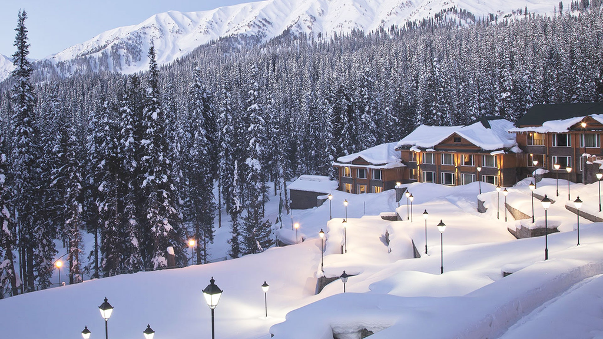

Python

[output not shown]

18/22

## $\LaTeX$ in Slides

Use `$ $` or `$$ $$` to display latex in Markdown, or embed images of equations

$\LaTeX$ needs time to load, so `slides.pre_compute_display()` will help

\$\$\int_0^1\frac{1}{1-x^2}dx\$\$

$$\int_0^1\frac{1}{1-x^2}dx$$

19/22

## Built-in CSS styles

Use any or combinations of these styles in className argument of writing functions: className = 'Center' ------Text------ className = 'Left' Text------------ className = 'Right' ------------Text className = 'RTL' ------ اردو عربی className = 'Info' Blue Text className = 'Warning' Orange Text className = 'Success' Green Text className = 'Error' Red Text className = 'Note' Text with info icon className = 'slides-only' Text will not appear in exported html with `build_report` className = 'report-only' Text will not appear on slides. Useful to fill content in report.

Info

Warning

سارے جہاں میں دھوم ہماری زباں کی ہے۔

Python

```
with slides.print_context():
    slides.css_styles

slides.write('Info',className='Info')
slides.write('Warning',className='Warning')
slides.write('سارے جہاں میں دھوم ہماری زباں کی ہے۔',className='Right RTL')
```

20/22

## This is all code to generate slides

Python

````
#Author: Abdul Saboor
# This demonstrates that you can generate slides from a .py file too, which you can import in notebook.
import textwrap, time
from io import StringIO
from IPython import get_ipython
from .utils import textbox
from .writers import write, iwrite
from .formatter import libraries, plt2html, __reprs__
from ._base.intro import how_to_slide

slides = get_ipython().user_ns['_s_l_i_d_e_s_'] # get slides from notebook instead of creating new one
slides.settings.set_footer('Author: Abdul Saboor عبدالصبور')
slides.settings.set_logo('''<svg viewBox="0 0 100 100" xmlns="http://www.w3.org/2000/svg">
        <circle cx="50" cy="50" r="50" fill="blue"/>
        <text x="45%" y="45%" fill="white" font-size="4em" dominant-baseline="central" text-anchor="middle">↑</text>
        <text x="55%" y="60%" fill="white" font-size="4em" dominant-baseline="central" text-anchor="middle">↓</text></svg>''',width=50)

#Demo for loading slides from a file or file-like object
fp = StringIO('\n'.join(how_to_slide) + '''\n---
# Slide 1 {.Success}
```python run source
import ipyslides as isd
version = isd.__version__
%xmd #### This is inline markdown parsed by magic {.Note .Warning}
```
Version: {{version}} as executed from below code in markdown.
{{source}}
---
# Slide 2 {.Success}
Created using `%%slide 2 -m` with markdown only
```multicol
# Column A
||### Sub column A {.Success}||### Sub column B ||
+++
# Column B
```
That version from last slide is still in memory. See it is there {{version}}
''')
slides.from_markdown(fp) # This will create first slide along with title page.

with slides.slide(1): #slide 1 will be modified with old and new content
    with slides.source.context(style='monokai', color='white', className='Mono') as s:
        slides.parse_xmd(slides.md_content[1])
        #display(*get_ipython().user_ns['outputs'])
        write('## I am created using `with slides.slide(1)` context( manager!')
        write(f'I am {slides.alert("Alerted")} and I am *{slides.colored("colored and italic text","magenta","whitesmoke")}*')
    write(s.focus_lines([0]))  #focus on line 0
    slides.notes.insert('### Note for slide 1')

slides.shell.user_ns['write'] = write #Inject variable in IPython shell

#slide 2
slides.shell.run_cell_magic('slide','2 -m',slides.md_content[2])
#slide 3
online_sources = '''# IPySlides Online Running Sources
Launch as voila slides (may not work as expected [^1])[![Binder](https://mybinder.org/badge_logo.svg)](https://mybinder.org/v2/gh/massgh/ipyslides-voila/HEAD?urlpath=voila%2Frender%2Fnotebooks%2Fipyslides.ipynb)
{.Note .Error}

[Edit on Kaggle](https://www.kaggle.com/massgh/ipyslides)\n{.Note .Warning}

Launch example Notebook [![Binder](https://mybinder.org/badge_logo.svg)](https://mybinder.org/v2/gh/massgh/ipyslides-voila/HEAD?urlpath=lab%2Ftree%2Fnotebooks%2Fipyslides.ipynb)
{.Note .Success}

[^1]: Add references like this per slide. Use slides.cite() to add citations generally.
'''
@slides.frames(3,'## I am created using `@slides.frames`',online_sources)
def func(obj):
    with slides.source.context() as s:
        slides.write(obj)
        slides.notify_later()(lambda: 'That is a notification which shows you can use decorator this way as well')
    write(s)

#Now generate many slides in a loop
__contents = [f"""## IPython Display Objects
#### Any object with following methods could be in`write` command:
{', '.join([f'`_repr_{rep}_`' for rep in __reprs__])}
Such as `IPython.display.<HTML,SVG,Markdown,Code>` etc. or third party such as `plotly.graph_objects.Figure`{{.Warning}}.
""",
f"""## Plots and Other **Data**{{style='color:var(--accent-color);'}} Types
#### These objects are implemented to be writable in `write` command:
{', '.join([f"`{lib['name']}.{lib['obj']}`" for lib in libraries])}
Many will be extentended in future. If an object is not implemented, use `display(obj)` to show inline or use library's specific
command to show in Notebook outside `write`.
""",
f"""## Interactive Widgets
### Any object in `ipywidgets`{textbox('<a href="https://ipywidgets.readthedocs.io/en/latest/">Link to ipywidgtes right here using `textbox` command</a>')}
or libraries based on ipywidgtes such as `bqplot`,`ipyvolume`,plotly's `FigureWidget`{slides.cite('pf','This is refernce to FigureWidget using `slides.cite` command')}(reference at end)
can be included in `iwrite` command as well as other objects that can be passed to `write` with caveat of Javascript.
{{.Warning}}
""",
'## Commands which do all Magic!']
for i in range(4,8):
    with slides.slide(i, background='skyblue'):
        write(__contents[i-4])
        if i == 7:
            with slides.source.context() as s:
                write([slides.doc(write,'LiveSlides'), slides.doc(iwrite,'LiveSlides'), slides.doc(slides.parse_xmd,'LiveSlides')])
                write("#### If an object does not render as you want, use `display(object)` or it's own library's mehod to display inside Notebook.")

            write(s.show_lines([0,1]))
# Matplotlib
with slides.slide(8,background='linear-gradient(to right, #FFDAB9 0%, #F0E68C 100%)'):
    write('## Plotting with Matplotlib')
    with slides.source.context() as s:
        import numpy as np, matplotlib.pyplot as plt
        x = np.linspace(0,2*np.pi)
        with plt.style.context('ggplot'):
            fig, ax = plt.subplots(figsize=(3.4,2.6))
            _ = ax.plot(x,np.cos(x))
        write([ax, s.focus_lines([1,3,4])])


# Youtube
from IPython.display import YouTubeVideo
with slides.slide(9):
    with slides.source.context(style='vs',className="Youtube") as s:
        write(f"### Watching Youtube Video?")
        write(YouTubeVideo('Z3iR551KgpI',width='100%',height='266px'))
        @slides.notify_later()
        def push():
            t = time.localtime()
            return f'You are watching Youtube at Time-{t.tm_hour:02}:{t.tm_min:02}'

        write(s) # source.context(style='vs',background='#FAA',className="Youtube")

# Data Table
with slides.slide(10):
    with slides.source.context() as s:
        write('## Data Tables')
        write(slides.block_r('Here is Table',
            textwrap.dedent('''
            |h1|h2|h3|
            |---|---|---|
            |d1|d2|d3|
            |r1|r2|r3|
            ''')))
        write(s.focus_lines([3,4,5,6]))
````

```
# Plotly and Pandas DataFrame only show if you have installed
with slides.slide(11,background='#800000'):
    with slides.source.context():
        try:
            import pandas as pd
            import altair as alt
            alt.themes.enable('dark')
            df = pd.read_csv('https://raw.githubusercontent.com/mwaskom/seaborn-data/master/iris.csv')
            chart = alt.Chart(df,width=300,height=260).mark_circle(size=60).encode(
                x='sepal_length',
                y='sepal_width',
                color='species',
                size = 'petal_width',
                tooltip=['species', 'sepal_length', 'sepal_width','petal_width','petal_length']
                ).interactive()
            df = df.describe() #Small for display
        except:
            df = '### Install `pandas` to view output'
            chart = '### Install Altair to see chart'
        write(('## Writing Pandas DataFrame',df),
            ('## Writing Altair Chart\nMay not work everywhere, needs javascript\n{.Note .Warning}',chart)
            )
    write(slides.source.current.show_lines(range(5,12))) #Show source code of above block even without assignning to variable explicitly

try:
    import plotly.graph_objects as go
    fig = go.Figure()
    fig.add_trace(go.Bar([1,5,8,9]))
except:
    fig = '### Install `plotly` to view output'
with slides.slide(12):
    write(('## Writing Plotly Figure',fig))

# Interactive widgets can't be used in write command, but still they are displayed.

with slides.slide(13):
    with slides.source.context() as src:
        import ipywidgets as ipw
        import numpy as np, matplotlib.pyplot as plt

        write('## Interactive Apps on Slide\n Use `ipywidgets`, `bqplot`,`ipyvolume` , `plotly Figurewidget` etc. to show live apps like this!')
        grid, [(plot,button, _), code] = slides.iwrite([
            '## Plot will be here! Click button below to activate it!',
            ipw.Button(description='Click me to update race plot',layout=ipw.Layout(width='max-content')),
            "[Check out this app](https://massgh.github.io/pivotpy/Widgets.html#VasprunApp)"],src.focus_lines([4,5,6,7,*range(24,30)]))

        def update_plot():
            x = np.linspace(0,0.9,10)
            y = np.random.random((10,))
            _sort = np.argsort(y)

            fig,ax = plt.subplots(figsize=(3.4,2.6))
            ax.barh(x,y[_sort],height=0.07,color=plt.cm.get_cmap('plasma')(x[_sort]))

            for s in ['right','top','bottom']:
                ax.spines[s].set_visible(False)

            ax.set(title='Race Plot', ylim = [-0.05,0.95], xticks=[],yticks=[c for c in x],yticklabels=[rf'$X_{int(c*10)}$' for c in x[_sort]])
            global plot # only need if you want to change something on it inside function
            plot = grid.update(plot, fig) #Update plot each time

        def onclick(btn):
            plot_theme = 'dark_background' if 'Dark' in slides.settings.theme_dd.value else 'default'
            with plt.style.context(plot_theme):
                update_plot()

        button.on_click(onclick)
        update_plot() #Initialize plot

    slides.notes.insert('## Something to hide from viewers!')


# Animat plot in slides
@slides.frames(14,*range(14,19))
def func(obj):
    with slides.source.context() as s:
        fig, ax = plt.subplots()
        x = np.linspace(0,obj+1,50+10*(obj - 13))
        ax.plot(x,np.sin(x));
        ax.set_title(f'$f(x)=\sin(x)$, 0 < x < {obj - 13}')
        ax.set_axis_off()
        slides.notes.insert(f'## This is under @frames decorator, so it will be shown only in first frame')
        slides.notify_later()(lambda: f'This is under @frames decorator, so it will be shown only in first frame')

    slides.write([f'### This is Slide {14}.{obj-13}\n and we are animating matplotlib',
                  s.show_lines([obj-14])
                  ],ax,width_percents=[40,60])
    if obj == 14:
        slides.write(s.show_lines([5,6]))

# Frames structure
boxes = [f'<div style="background:var(--tr-hover-bg);width:auto;height:auto;padding:8px;margin:8px;border-radius:4px;"><h1>{i}</h1></div>' for i in range(1,10)]
@slides.frames(15,*boxes, repeat=False)
def f(obj):
    slides.write('# Frames with \n#### `repeat = False`')
    slides.write(obj)

@slides.frames(16,*boxes, repeat=True)
def f(obj):
    slides.write('# Frames with \n#### `repeat = True`')
    slides.write(*obj,className='Warning')

@slides.frames(17,*boxes, repeat=[(0,1,2),(3,4,5),(6,7,8)])
def f(obj):
    with slides.source.context() as s:
        slides.write('# Frames with \n#### `repeat = [(0,1,2),(3,4,5),(6,7,8)]`')
        slides.write(*obj)
    slides.write(s)

with slides.slide(18):
    with slides.source.context() as s:
        slides.write(['## Displaying image from url from somewhere in Kashmir (کشمیر)',
                      slides.image(r'https://assets.gqindia.com/photos/616d2712c93aeaf2a32d61fe/master/pass/top-image%20(1).jpg')],
                     className='Success')
    slides.write(s)

with slides.slide(19):
    slides.write('## $\LaTeX$ in Slides\nUse `$ $` or `$$ $$` to display latex in Markdown, or embed images of equations')
    slides.write('$\LaTeX$ needs time to load, so `slides.pre_compute_display()` will help\n{.Note .Warning}')
    slides.write([r'\$\$\int_0^1\frac{1}{1-x^2}dx\$\$',
                r'$$\int_0^1\frac{1}{1-x^2}dx$$'
                ])

with slides.slide(20):
    slides.write('## Built-in CSS styles')
    with slides.source.context() as s:
        with slides.print_context():
            slides.css_styles

        slides.write('Info',className='Info')
        slides.write('Warning',className='Warning')
        slides.write('سارے جہاں میں دھوم ہماری زباں کی ہے۔',className='Right RTL')
    slides.write(s)
```

Python

```
def demo(self):
    """Demo slides with a variety of content."""
    self._check_computed('load demo')
    get_ipython().user_ns['_s_l_i_d_e_s_'] = self
    from .. import _demo
    slides = _demo.slides # or it is self
    with slides.slide(100):
        slides.write('## This is all code to generate slides')
        slides.write(_demo)
        slides.write(self.demo)
    with slides.slide(101,background='#9ACD32'):
        with slides.source.context() as s:
            slides.write_citations()
        slides.write(s)

    slides.progress_slider.index = 0 # back to title
    return slides
```

21/22

### References

<sup>1</sup>This is refernce to FigureWidget using `slides.cite` command

Python

```
slides.write_citations()
```

22/22